# ZOMATO

# 1-Problem:

in our project we chose the dataset of the restaurants in Zomato which is an Indian multinational restaurant aggregator and food delivery company. This dataset contains information about various restaurants listed on the platform, including their location, cuisine type, ratings, and other essential attributes.we will study and analyze the restaurants data that will help us identify the preferred cost range and the most likable restaurant type and cuisines type that leads into high ratings to help people who are interested in putting their restaurants on the platform by predicting the ratings of new restaurants on the platform.

2-Data Mining Task:

3- Data set information:

We choose this data from Kaggle website(https://www.kaggle.com/datasets/abhijitdahatonde/zomato-restaurants-dataset) This dataset provides us with information about different type of restaurant and there ratings in food application called Zomato, it consists the following attributes:

##Data set info: Number of attributes:12

| Attribute | Description | Type | Possible values |
| --- | --- | --- | --- |
| # | Index | Numeric-Ratio | [0-7014] |
| Restauran name | Name of restaurant that application offered by the application | Nominal | #FeelTheROLL #L-81 Cafe #refuel’@ Biryani Central’@ The Bbq |
| Restaurant type | restaurant type includes the type of the restaurant and if it has delivery or takeaway | Nominal | Quick Bites ,Casual Dining, Cafe, Delivery Takeaway |
| Rate | Express your opinion or assessme | Numeric- Interval | [1.8-4.9] |
| Number of ratings | refers the count of how many times a restaurant or product has been rated or reviewed by customer or user | Numeric- Interval | [1-16,300] |
| Avg cost | Total cost of order | Numeric- Interval | [40-6000] |
| Online order | This means that customers have the option to place their food orders through the restaurant’s website or a dedicated online ordering platform | Binary (Asymmetric) | 1(Yes),0(No) |
| Teble booking | This refers to the process of reserving a table at a restaurant in advance | Binary (Asymmetric) | 1(Yes),0(No) |
| Cuisines type | This represents the style or category of food and dishes that a restaurant specializes in or offers | Nominal | North Indian ,Chinese ,North Indian,Fast Food |

Sample of data:

```r
print(zomato)
```

| ...1 | Unnamed: 0 | restaurantname | restauranttype | rate | numofratings | avgCost | online_order | tablebooking | cuisinestype | area | localaddress |
| --- | --- | --- | --- | --- | --- | --- | --- | --- | --- | --- | --- |
| 0 | 0 | #FeelTheROLL | Quick Bites | 3.4 | 7 | 200 | No | No | Fast Food | Bellandur | Bellandur |
| 1 | 1 | #L-81 Cafe | Quick Bites | 3.9 | 48 | 400 | Yes | No | Fast Food, Beverages | Byresandra,Tavarekere,Madiwala | HSR |
| 2 | 2 | #refuel | Cafe | 3.7 | 37 | 400 | Yes | No | Cafe, Beverages | Bannerghatta Road | Bannerghatta Road |
| 3 | 3 | '@ Biryani Central | Casual Dining | 2.7 | 135 | 550 | Yes | No | Biryani, Mughlai, Chinese | Marathahalli | Marathahalli |
| 4 | 4 | '@ The Bbq | Casual Dining | 2.8 | 40 | 700 | Yes | No | BBQ, Continental, North Indian, Chinese, Beverages | Bellandur | Bellandur |
| 5 | 5 | '@99 | Takeaway, Delivery | 3.4 | 37 | 200 | No | No | Mughlai, Biryani, Chinese, North Indian | Whitefield | Whitefield |
| 6 | 6 | '@Italy | Casual Dining | 4.1 | 305 | 700 | Yes | No | Italian | Banashankari | Kumaraswamy Layout |
| 7 | 7 | '@North Parontha Hut | Takeaway, Delivery | 2.8 | 40 | 300 | No | No | North Indian | Indiranagar | Old Airport Road |
| 8 | 8 | 1000 B.C | Quick Bites | 3.2 | 49 | 300 | Yes | No | Arabian, Sandwich, Rolls, Burger | Byresandra,Tavarekere,Madiwala | Koramangala 5th Block |
| 9 | 9 | 100ÃÂÃÂÃÂÃÂÃÂÃÂÃÂÃÂ°C | Casual Dining | 3.7 | 41 | 450 | No | No | Biryani, North Indian | Byresandra,Tavarekere,Madiwala | BTM |

[output cut: 990 more lines]

[output not shown]

Data

```r
zomato <- read.csv("zomato.csv")
```

```r
summary(zomato)
```

```
      ...1        Unnamed: 0   restaurantname     restauranttype          rate        numofratings
 Min.   :   0   Min.   :   0   Length:7105        Length:7105        Min.   :1.800   Min.   :    1.0
 1st Qu.:1776   1st Qu.:1776   Class :character   Class :character   1st Qu.:3.200   1st Qu.:   16.0
 Median :3552   Median :3552   Mode  :character   Mode  :character   Median :3.500   Median :   40.0
 Mean   :3552   Mean   :3552                                         Mean   :3.514   Mean   :  188.9
 3rd Qu.:5328   3rd Qu.:5328                                         3rd Qu.:3.800   3rd Qu.:  128.0
 Max.   :7104   Max.   :7104                                         Max.   :4.900   Max.   :16345.0
                                                                     NA's   :68
    avgCost       online_order       tablebooking       cuisinestype           area
 Min.   :  40.0   Length:7105        Length:7105        Length:7105        Length:7105
 1st Qu.: 300.0   Class :character   Class :character   Class :character   Class :character
 Median : 400.0   Mode  :character   Mode  :character   Mode  :character   Mode  :character
 Mean   : 540.3
 3rd Qu.: 600.0
 Max.   :6000.0
 NA's   :57
 localaddress
 Length:7105
 Class :character
 Mode  :character
```

```r
head(zomato)
```

| ...1 | Unnamed: 0 | restaurantname | restauranttype | rate | numofratings | avgCost | online_order | tablebooking | cuisinestype | area | localaddress |
| --- | --- | --- | --- | --- | --- | --- | --- | --- | --- | --- | --- |
| 0 | 0 | #FeelTheROLL | Quick Bites | 3.4 | 7 | 200 | No | No | Fast Food | Bellandur | Bellandur |
| 1 | 1 | #L-81 Cafe | Quick Bites | 3.9 | 48 | 400 | Yes | No | Fast Food, Beverages | Byresandra,Tavarekere,Madiwala | HSR |
| 2 | 2 | #refuel | Cafe | 3.7 | 37 | 400 | Yes | No | Cafe, Beverages | Bannerghatta Road | Bannerghatta Road |
| 3 | 3 | '@ Biryani Central | Casual Dining | 2.7 | 135 | 550 | Yes | No | Biryani, Mughlai, Chinese | Marathahalli | Marathahalli |
| 4 | 4 | '@ The Bbq | Casual Dining | 2.8 | 40 | 700 | Yes | No | BBQ, Continental, North Indian, Chinese, Beverages | Bellandur | Bellandur |
| 5 | 5 | '@99 | Takeaway, Delivery | 3.4 | 37 | 200 | No | No | Mughlai, Biryani, Chinese, North Indian | Whitefield | Whitefield |

[output not shown]

```r
sum(is.na(zomato))
```

```
[1] 125
```

## Boxplot

```r
boxplot.stats(zomato$rate)$out
```

```
 [1] 1.8 4.9 2.1 4.7 4.8 2.0 4.7 2.3 4.7 4.9 2.3 4.7 2.1 4.7 4.7 2.0 4.7 2.1 2.2 2.1 4.7 2.3 2.1 4.8 4.8 2.3
[27] 4.9 4.7 2.2 2.2 4.7 4.7 4.7 4.8 4.7 2.3 2.3 2.3 4.7
```

```r
boxplot.stats(zomato$avgCost)$out
```

```
  [1] 1500 2000 1400 2500 1400 3000 3000 1100 1100 1600 1400 1300 1100 1400 1300 1400 1800 4000 2000 2000 1200
 [22] 2500 1900 3000 1500 2000 1500 3000 2000 2000 1400 1800 2000 1500 1800 1200 1100 3400 1100 1200 1500 1100
 [43] 3700 1300 1100 3000 1500 1700 1100 1700 1500 2500 1300 1200 1600 1300 1500 2000 1400 1100 2400 1500 1500
 [64] 2200 2500 1400 1500 1800 1500 1600 1600 1100 1200 1500 1600 2400 1800 1400 1200 1400 1200 1300 2100 1200
 [85] 1500 2500 3200 2000 1500 1500 1200 1500 1500 1100 1800 1300 1200 1800 1400 1200 1200 1400 1400 1500 1400
[106] 1600 1500 1100 1300 1800 1600 1200 1300 1300 1500 1500 1200 1500 1100 1500 1700 1600 1700 1700 1700 1200
[127] 1100 1600 1300 2500 1500 2000 2200 3000 1200 2800 1100 1400 1100 1200 1200 1400 1400 1200 1300 1100 2500
[148] 1500 1400 1200 2500 1500 1600 1100 1200 1500 1500 1100 1400 1500 1500 1400 3500 1900 2200 1100 1500 1500
[169] 1200 1200 1400 1100 1200 2500 1400 4000 1500 1300 1100 1100 1800 1300 1500 2000 1300 1500 2500 4000 2200
[190] 1100 1500 1100 4000 1100 1400 1200 1300 1900 1600 1200 1250 1250 1100 1500 1500 1200 1500 2000 2500 1500
[211] 1600 1200 1200 1200 1500 2600 1900 1200 1400 1500 1800 1500 1800 1200 1200 2000 1500 1600 1400 1200 2000
[232] 1900 1400 1400 1200 1100 4000 1500 1200 1200 1100 1100 1200 1200 1500 2500 2000 1400 1200 1200 1250 1800
[253] 2600 1400 1300 1100 1300 3000 3000 2800 2500 2500 3000 1500 1250 1400 2700 1600 2500 2000 1600 1200 1300
[274] 4000 2000 1300 1800 1650 1100 1700 1500 1100 2200 1400 3500 2000 1500 1800 1200 3000 3000 3500 1200 1200
[295] 1500 3000 2000 1300 1500 1200 1500 1200 1200 1100 2000 4100 1500 1300 2000 1600 2000 6000 3000 2000 1500
```

[output cut: 17 more lines]

```r
boxplot.stats(zomato$numofratings)$out
```

```
  [1]   305  2861   353  1731  1509   620   595   419   932   344  1234   556  1149   662   399   737  1763
 [18]   478   531   458  2871   544   888   574  1502   405   377   783   867   336  1413   567   370   561
 [35]   682   346   446   704   387   314   821   568   435  1428   317   739   434   461   730   841   474
 [52]   339  8375   533   449   861  2178  1229   577   506   610   734   429   504   634   479   903   527
 [69]  1383   532  1014   477   612  2212   764   474  1003  1303  1316   592  2445   842  4650   496   345
 [86]   869   419   367   415   456   391   541   521   858  1899   859   426   854   418   779  1550   662
[103]   320   746  6865   555  9272   678   347   317   301   751   298   627  1071   618  1845   400   318
[120]  1214   733   935   514   505   401   330  1721   866   717  2355   555  2616  1636   601   700   973
[137]  1187  5894   970  2329  4321  1633   387  1142  3870   879   356   351  3125   345  2448  1594   605
[154]   782  1345 16345  1989  1233   402   688   721   721   500   559   388   869   496   351  1048  1654
[171]  1059   513   563   583   500   373   577   431   424   559   719   540  1423   980   600   341   842
[188]   343   405   420   444   825  1275   997   342  2233   960   353   395   319  4955   378   307   455
[205]  2658   445   358   746   557   308  7544  1403  2339  1269   331   589   417   364   466  3998   820
[222]  2589   583  4408   678   306   507   739   334   325   384   475   409  2487   505   909  3423   498
[239]   361   344  1414  1287   463  1800   372   798  2316   758  1341   652   297   371  2651  1445   344
```

[output cut: 41 more lines]

#description Rating depend in the reviewer’s preferences, these ratings are subjective and can change over time, by this boxplot we can determine the outliers which are few.

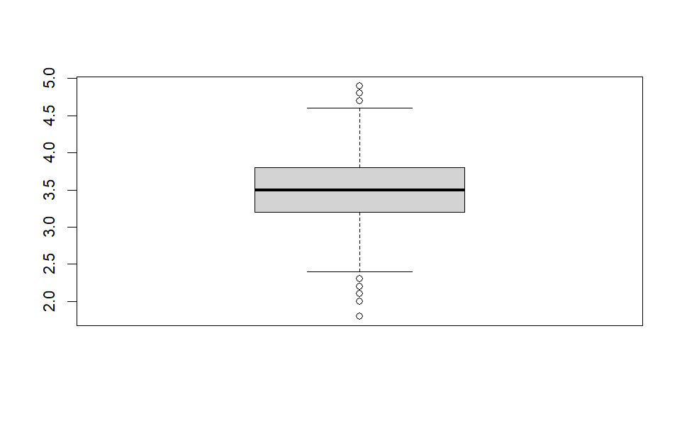

```r
boxplot(zomato$rate)
```

#### description:

The number of rating boxplot shows that value are close and there hug verity of numbers and a lot of ouliers.

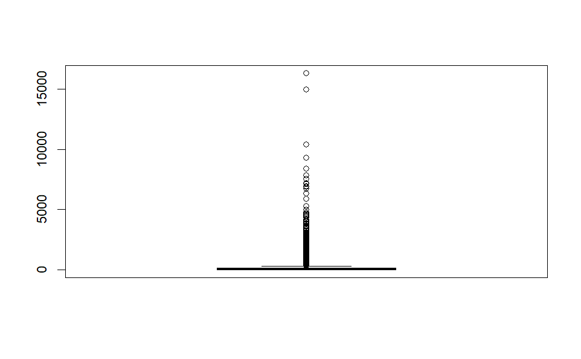

```r
boxplot(zomato$numofratings)
```

#### description:

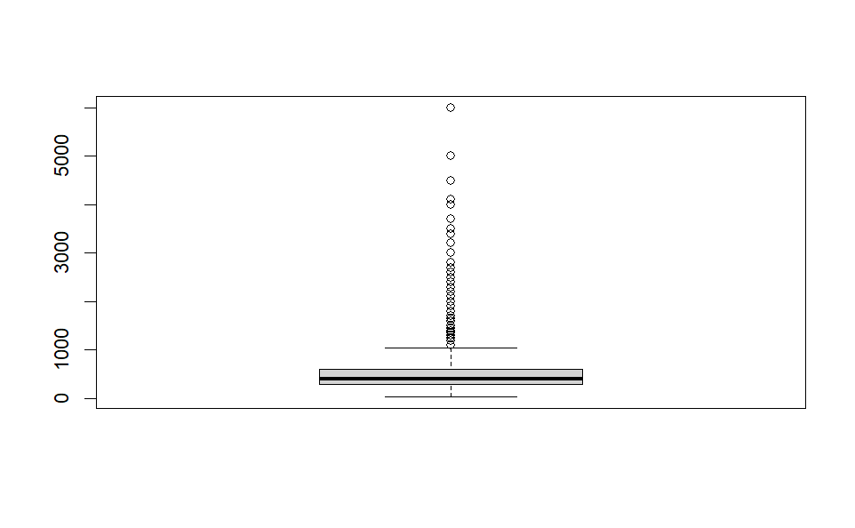

```r
boxplot(zomato$avgCost)
```

#### description:

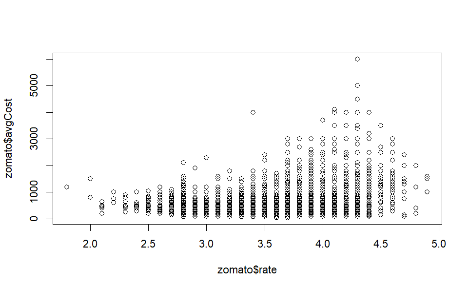

```r
plot(zomato$rate,zomato$avgCost)
```

##This histogram show the frequency average cost, by looking we can se that most people spends between 0-1000

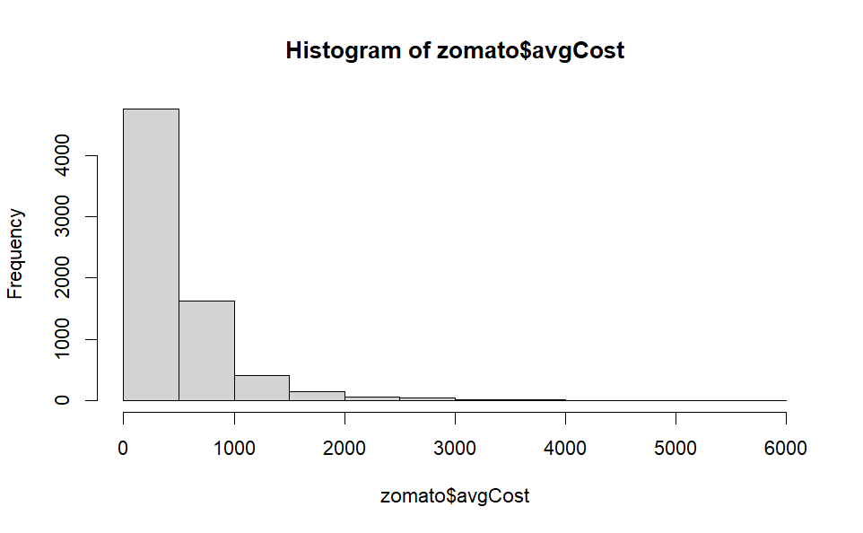

```r
hist(zomato$avgCost)
```

This pie chart shows if the restaurants offer online order or not, looking at it we can see that they are slightly similar.

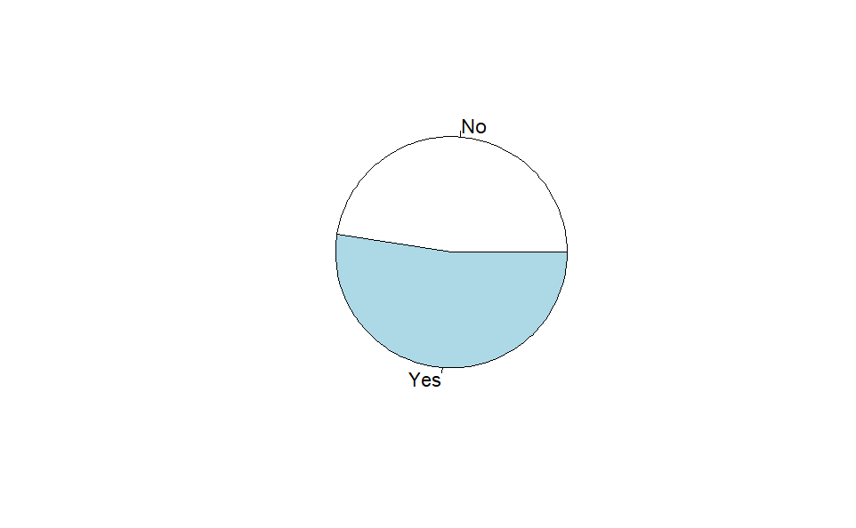

```r
onlineOrder <- table(zomato$online_order)
pie(onlineOrder)
```

## Statistical Measures

The statistical measures in R, such as mean, standard deviation, median, and others, are primarily applied to numeric data. These measures help in summarizing, describing, and understanding the properties and characteristics of numerical data. When applied to numeric data, they provide valuable insights and descriptive statistics that aid in understanding the distribution, central tendency, variability, and other important characteristics of the dataset.

Numeric statistical measures in R are specifically designed to work with numerical data to derive insights and statistical summaries.

```r
summary (zomato$rate)
```

```
   Min. 1st Qu.  Median    Mean 3rd Qu.    Max.    NA's
  1.800   3.200   3.500   3.514   3.800   4.900      68
```

```r
summary(zomato$numofratings)
```

```
   Min. 1st Qu.  Median    Mean 3rd Qu.    Max.
    1.0    16.0    40.0   188.9   128.0 16345.0
```

```r
summary(zomato$avgCost)
```

```
   Min. 1st Qu.  Median    Mean 3rd Qu.    Max.    NA's
   40.0   300.0   400.0   540.3   600.0  6000.0      57
```

Data Preprocessing:

Check for missing value:

```r
dim(zomato)
```

```
[1] 7105   12
```

```r
zomato =na.omit(zomato)
```

```r
dim(zomato)
```

```
[1] 6984   12
```

```r
sum(is.na(zomato))
```

```
[1] 0
```

### Description:

Missing or null values can significantly impact the effectiveness of a dataset and the quality of insights that can be derived from it. Therefore, we conducted an examination of our data to identify and eliminate any rows containing missing or null values. This process was undertaken to enhance the overall efficiency and reliability of our dataset, ensuring more accurate analysis and valuable information extraction in subsequent steps.

## Detecting and removing the outliers

### Detecting the outliers:

Initially, we detected any unusual data points in the numerical attributes. Subsequently, we removed the rows containing these outliers in order to create a more precise dataset, which would ultimately enhance the accuracy of our later results.

```r
library(outliers)
```

#Detect outliers in the ‘numofratings’ column of the ‘zomato’ dataset.

```r
OutN = outlier(zomato$numofratings, logical =TRUE)
```

Sum the number of outliers detected.

```r
sum(OutN)
```

```
[1] 1
```

Find the indices of the outliers in the ‘numofratings’ column.

```r
Find_outlier = which(OutN ==TRUE, arr.ind = TRUE)
```

Display the logical vector indicating outliers.

```r
OutN
```

```
   [1] FALSE FALSE FALSE FALSE FALSE FALSE FALSE FALSE FALSE FALSE FALSE FALSE FALSE FALSE FALSE FALSE FALSE
  [18] FALSE FALSE FALSE FALSE FALSE FALSE FALSE FALSE FALSE FALSE FALSE FALSE FALSE FALSE FALSE FALSE FALSE
  [35] FALSE FALSE FALSE FALSE FALSE FALSE FALSE FALSE FALSE FALSE FALSE FALSE FALSE FALSE FALSE FALSE FALSE
  [52] FALSE FALSE FALSE FALSE FALSE FALSE FALSE FALSE FALSE FALSE FALSE FALSE FALSE FALSE FALSE FALSE FALSE
  [69] FALSE FALSE FALSE FALSE FALSE FALSE FALSE FALSE FALSE FALSE FALSE FALSE FALSE FALSE FALSE FALSE FALSE
  [86] FALSE FALSE FALSE FALSE FALSE FALSE FALSE FALSE FALSE FALSE FALSE FALSE FALSE FALSE FALSE FALSE FALSE
 [103] FALSE FALSE FALSE FALSE FALSE FALSE FALSE FALSE FALSE FALSE FALSE FALSE FALSE FALSE FALSE FALSE FALSE
 [120] FALSE FALSE FALSE FALSE FALSE FALSE FALSE FALSE FALSE FALSE FALSE FALSE FALSE FALSE FALSE FALSE FALSE
 [137] FALSE FALSE FALSE FALSE FALSE FALSE FALSE FALSE FALSE FALSE FALSE FALSE FALSE FALSE FALSE FALSE FALSE
 [154] FALSE FALSE FALSE FALSE FALSE FALSE FALSE FALSE FALSE FALSE FALSE FALSE FALSE FALSE FALSE FALSE FALSE
 [171] FALSE FALSE FALSE FALSE FALSE FALSE FALSE FALSE FALSE FALSE FALSE FALSE FALSE FALSE FALSE FALSE FALSE
 [188] FALSE FALSE FALSE FALSE FALSE FALSE FALSE FALSE FALSE FALSE FALSE FALSE FALSE FALSE FALSE FALSE FALSE
 [205] FALSE FALSE FALSE FALSE FALSE FALSE FALSE FALSE FALSE FALSE FALSE FALSE FALSE FALSE FALSE FALSE FALSE
 [222] FALSE FALSE FALSE FALSE FALSE FALSE FALSE FALSE FALSE FALSE FALSE FALSE FALSE FALSE FALSE FALSE FALSE
 [239] FALSE FALSE FALSE FALSE FALSE FALSE FALSE FALSE FALSE FALSE FALSE FALSE FALSE FALSE FALSE FALSE FALSE
```

[output cut: 45 more lines]

Display the indices of the outliers.

```r
Find_outlier
```

```
[1] 1019
```

#### Remove rows with outliers from the ‘zomato’ dataset.

```r
zomato= zomato[-Find_outlier,]
```

We replicated the procedures outlined in the previous code but with the column avgCost.

```r
OutAv = outlier(zomato$avgCost, logical =TRUE)
sum(OutAv)
```

```
[1] 1
```

```r
Find_outlier = which(OutAv ==TRUE, arr.ind = TRUE)
OutAv
```

```
   [1] FALSE FALSE FALSE FALSE FALSE FALSE FALSE FALSE FALSE FALSE FALSE FALSE FALSE FALSE FALSE FALSE FALSE
  [18] FALSE FALSE FALSE FALSE FALSE FALSE FALSE FALSE FALSE FALSE FALSE FALSE FALSE FALSE FALSE FALSE FALSE
  [35] FALSE FALSE FALSE FALSE FALSE FALSE FALSE FALSE FALSE FALSE FALSE FALSE FALSE FALSE FALSE FALSE FALSE
  [52] FALSE FALSE FALSE FALSE FALSE FALSE FALSE FALSE FALSE FALSE FALSE FALSE FALSE FALSE FALSE FALSE FALSE
  [69] FALSE FALSE FALSE FALSE FALSE FALSE FALSE FALSE FALSE FALSE FALSE FALSE FALSE FALSE FALSE FALSE FALSE
  [86] FALSE FALSE FALSE FALSE FALSE FALSE FALSE FALSE FALSE FALSE FALSE FALSE FALSE FALSE FALSE FALSE FALSE
 [103] FALSE FALSE FALSE FALSE FALSE FALSE FALSE FALSE FALSE FALSE FALSE FALSE FALSE FALSE FALSE FALSE FALSE
 [120] FALSE FALSE FALSE FALSE FALSE FALSE FALSE FALSE FALSE FALSE FALSE FALSE FALSE FALSE FALSE FALSE FALSE
 [137] FALSE FALSE FALSE FALSE FALSE FALSE FALSE FALSE FALSE FALSE FALSE FALSE FALSE FALSE FALSE FALSE FALSE
 [154] FALSE FALSE FALSE FALSE FALSE FALSE FALSE FALSE FALSE FALSE FALSE FALSE FALSE FALSE FALSE FALSE FALSE
 [171] FALSE FALSE FALSE FALSE FALSE FALSE FALSE FALSE FALSE FALSE FALSE FALSE FALSE FALSE FALSE FALSE FALSE
 [188] FALSE FALSE FALSE FALSE FALSE FALSE FALSE FALSE FALSE FALSE FALSE FALSE FALSE FALSE FALSE FALSE FALSE
 [205] FALSE FALSE FALSE FALSE FALSE FALSE FALSE FALSE FALSE FALSE FALSE FALSE FALSE FALSE FALSE FALSE FALSE
 [222] FALSE FALSE FALSE FALSE FALSE FALSE FALSE FALSE FALSE FALSE FALSE FALSE FALSE FALSE FALSE FALSE FALSE
 [239] FALSE FALSE FALSE FALSE FALSE FALSE FALSE FALSE FALSE FALSE FALSE FALSE FALSE FALSE FALSE FALSE FALSE
```

[output cut: 45 more lines]

```r
Find_outlier
```

```
[1] 3496
```

```r
zomato= zomato[-Find_outlier,]
```

```r
head(zomato)
```

| ...1 | Unnamed: 0 | restaurantname | restauranttype | rate | numofratings | avgCost | online_order | tablebooking | cuisinestype | area | localaddress |
| --- | --- | --- | --- | --- | --- | --- | --- | --- | --- | --- | --- |
| 0 | 0 | #FeelTheROLL | Quick Bites | 3.4 | 7 | 200 | No | No | Fast Food | Bellandur | Bellandur |
| 1 | 1 | #L-81 Cafe | Quick Bites | 3.9 | 48 | 400 | Yes | No | Fast Food, Beverages | Byresandra,Tavarekere,Madiwala | HSR |
| 2 | 2 | #refuel | Cafe | 3.7 | 37 | 400 | Yes | No | Cafe, Beverages | Bannerghatta Road | Bannerghatta Road |
| 3 | 3 | '@ Biryani Central | Casual Dining | 2.7 | 135 | 550 | Yes | No | Biryani, Mughlai, Chinese | Marathahalli | Marathahalli |
| 4 | 4 | '@ The Bbq | Casual Dining | 2.8 | 40 | 700 | Yes | No | BBQ, Continental, North Indian, Chinese, Beverages | Bellandur | Bellandur |
| 5 | 5 | '@99 | Takeaway, Delivery | 3.4 | 37 | 200 | No | No | Mughlai, Biryani, Chinese, North Indian | Whitefield | Whitefield |

[output not shown]

```r
NA
```

##Encoding categorical data: Encoding plays a crucial role in various data mining and machine learning tasks, as it facilitates the transformation of raw data into a format that algorithms can effectively process and analyze. This process involves converting categorical or textual data into numerical representations, ensuring compatibility with the computational requirements of the algorithms involved.

##Normalize Data using Min-Max Scaling:

normalization was performed to ensure consistent scaling of the data. The normalization technique applied was the max-min normalization. This technique rescales the values of specific attributes within a defined range between 0 and 1. The following attributes were selected for normalization: numofrating, avgCost We can use the normalized dataset provides a more uniform and comparable representation of the attributes, enabling accurate analysis and modeling for rate.

```r
##Encoding:
zomato$tablebooking=factor(zomato$tablebooking , levels =c("No","Yes"), labels = c(0,1))
zomato$online_order=factor(zomato$online_order , levels =c("No","Yes"), labels = c(0,1))
##Normalization:
normalize <- function(x){return ((x-min(x))/(max(x)-min(x)))}
```

```r
##Normalization:
zomato$numofratings<- normalize(zomato$numofratings)
zomato$avgCost<- normalize(zomato$avgCost)

##Encoding:
zomato$rate <- ifelse(zomato$rate <= 2, "Bad",
                  ifelse(zomato$rate <=3, "Okay",
                      ifelse(zomato$rate <=4, "Good",
                             ifelse(zomato$rate <=5, "Great",0 ))))
```

```r
head(zomato)
```

| ...1 | Unnamed: 0 | restaurantname | restauranttype | rate | numofratings | avgCost | online_order | tablebooking | cuisinestype | area | localaddress |
| --- | --- | --- | --- | --- | --- | --- | --- | --- | --- | --- | --- |
| 0 | 0 | #FeelTheROLL | Quick Bites | Good | 0.0004012036 | 0.03225806 | 0 | 0 | Fast Food | Bellandur | Bellandur |
| 1 | 1 | #L-81 Cafe | Quick Bites | Good | 0.0031427616 | 0.07258065 | 1 | 0 | Fast Food, Beverages | Byresandra,Tavarekere,Madiwala | HSR |
| 2 | 2 | #refuel | Cafe | Good | 0.0024072217 | 0.07258065 | 1 | 0 | Cafe, Beverages | Bannerghatta Road | Bannerghatta Road |
| 3 | 3 | '@ Biryani Central | Casual Dining | Okay | 0.0089602140 | 0.10282258 | 1 | 0 | Biryani, Mughlai, Chinese | Marathahalli | Marathahalli |
| 4 | 4 | '@ The Bbq | Casual Dining | Okay | 0.0026078235 | 0.13306452 | 1 | 0 | BBQ, Continental, North Indian, Chinese, Beverages | Bellandur | Bellandur |
| 5 | 5 | '@99 | Takeaway, Delivery | Good | 0.0024072217 | 0.03225806 | 0 | 0 | Mughlai, Biryani, Chinese, North Indian | Whitefield | Whitefield |

[output not shown]

```r
NA
```

## Features selection:

```r
# load the library
 library(mlbench)
library(caret)
library(randomForest)
```

```r
# ensure the results are repeatable
set.seed(7)

# Convert the class label to a factor

zomato$rate <- as.factor(zomato$rate )



# Separate the predictors and the class label

predictors <- zomato[, -5]  # Excluding the class label (satisfaction)
class_label <- zomato$rate


# Train a Random Forest model

model <- randomForest(predictors, class_label, importance = TRUE)



# Get the variable importance

importance <- importance(model)

ranked_features <- sort(importance[, "MeanDecreaseGini"], decreasing = TRUE)



# Print the ranked features
print(ranked_features)
```

```
  numofratings        avgCost   cuisinestype           ...1 restaurantname     Unnamed: 0   localaddress
     1219.1567       286.0851       285.1132       255.2049       254.4841       254.0847       223.5770
          area restauranttype   tablebooking   online_order
      189.4437       155.5106       100.1596        56.1250
```

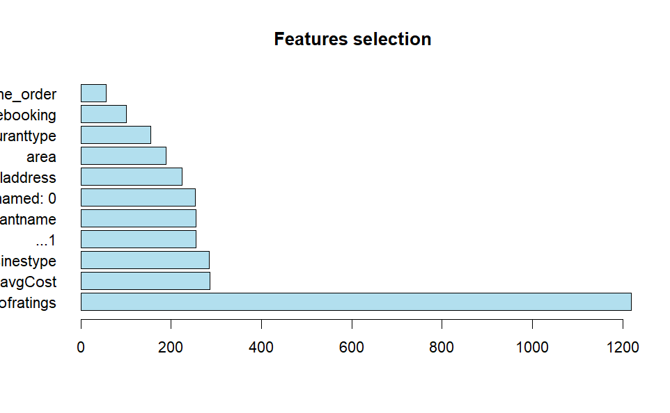

```r
barplot(ranked_features, horiz = TRUE, col = c("lightblue2"), las = 1, main = "Features selection")
```

##balance:

Balance or imbalance ?The provided code snippet in R performs a process known as data upscaling or oversampling. This technique is commonly used to address imbalances within categorical classes by generating additional instances of the underrepresented class.

```r
library(ROSE)
# upscaling the data

zomato$rate <- as.factor(zomato$rate)
zomato<-upSample(zomato[,-5],zomato$rate, yname="rate")
plot(zomato$rate)

# checking the number of stroke/ non-stroke observations
prop.table(table(zomato$rate))
```

```
  Bad  Good Great  Okay
 0.25  0.25  0.25  0.25
```

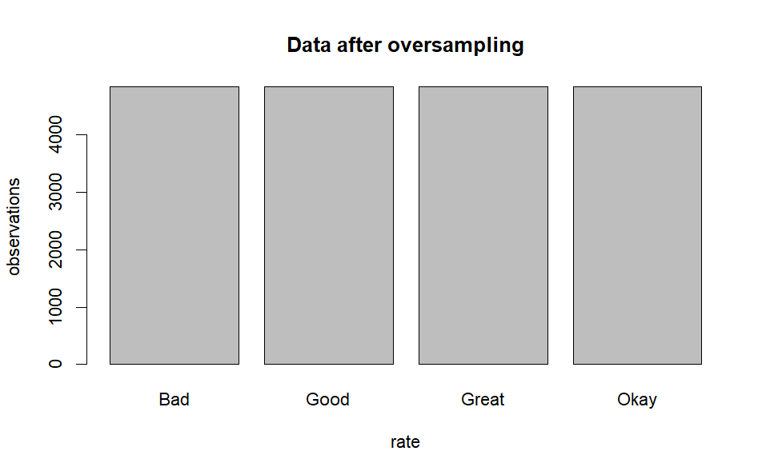

```r
title(main="Data after oversampling", xlab="rate", ylab="observations")
```

```r
NA
NA
NA
```

Classification: We employed both supervised and unsupervised learning methodologies on our dataset by leveraging classification and clustering techniques. For classification, we utilized a decision tree—a recursive algorithm generating a tree structure with leaf nodes that represent final decisions. Our model is geared towards predicting the class label (‘rate’), categorized into four classes: ‘Good,’ ‘Great,’ and ‘Bad ’Okaya’. The prediction is based on the remaining attributes (‘numRatin’ and ‘avgCost’). This technique involved the following steps:

Data Splitting: - Dividing the dataset into two distinct sets: - Training dataset: Employed for constructing the decision tree. - Testing dataset: Utilized to assess and validate the built model.

Methodologies and Techniques: - Data Splitting: Employed the ‘sample’ method to partition the dataset into training and testing subsets. # - Decision Tree Construction: Leveraged the ‘rpart.plot’ method for building the decision tree structure. # - Prediction and Testing: Utilized the ‘predict’ method to assess and test the model’s predictions. # - Model Evaluation: Employed the ‘confusionMatrix’ method to assess the model’s performance through the confusion matrix.